```python
# Comprobamos el environment
# ==============================================================================
import sys

print(sys.version)
print(sys.path)
print("---")
print(sys.executable)
```

```
3.12.7 | packaged by Anaconda, Inc. | (main, Oct  4 2024, 08:28:27) [Clang 14.0.6 ]
['/opt/anaconda3/envs/practica1b/lib/python312.zip', '/opt/anaconda3/envs/practica1b/lib/python3.12', '/opt/anaconda3/envs/practica1b/lib/python3.12/lib-dynload', '', '/Users/oscar/.local/lib/python3.12/site-packages', '/opt/anaconda3/envs/practica1b/lib/python3.12/site-packages', '/opt/anaconda3/en…
---
/opt/anaconda3/envs/practica1b/bin/python
```

# Explicabilidad del modelo final

El objetivo principal de este notebook es aplicar el modelo SHAP y obtener los valores SHAP para entender mejor cómo cada característica afecta las predicciones de mi modelo. Vamos a ver dos cosas importantes: por un lado, la explicabilidad global, para entender cómo las variables impactan el modelo en general, y por otro, la explicabilidad local, para ver cómo cada característica contribuye a las predicciones de casos específicos.

Es clave recordar que nunca deberíamos poner un modelo en funcionamiento sin antes estudiar bien cómo funciona y qué lo hace tomar decisiones. Solo así podemos asegurarnos de que el modelo es confiable y que sus decisiones tienen sentido.

# Librerías:

Las librerías utilizadas en este notebook son:

```python
# Manejo de datos
# ==============================================================================
import pandas as pd
import numpy as np

# Serialización y almacenamiento de modelos
# ==============================================================================
import pickle
from joblib import dump, load

# Modelos de clasificación
# ==============================================================================
from sklearn.linear_model import LogisticRegression

# Explicabilidad e interpretabilidad del modelo
# ==============================================================================
import shap
shap.initjs()
```

```python
# Configuración pandas
# ==============================================================================
pd.set_option('display.max_columns', 500)
pd.set_option('display.max_rows', 5000)

# Configuración warnings
# ==============================================================================
import warnings
warnings.filterwarnings('ignore')
```

# Datos:

Importamos los datasets procesados en el segundo notebook anterior, los cuales no incluyen la selección de variables realizada.

```python
# Datos de entrenamiento
# ==============================================================================
path_folder_train = "../data/interim/train_pd_data_preprocessing_features.csv"
pd_loan_train = pd.read_csv(path_folder_train)

# Datos de test
# ==============================================================================
path_folder_test = "../data/interim/test_pd_data_preprocessing_features.csv"
pd_loan_test = pd.read_csv(path_folder_test)
```

```python
# Datos de entrenamiento
# ==============================================================================
X_train_scaled_t = pd_loan_train.drop('TARGET', axis=1)
y_train = pd_loan_train['TARGET']

# Datos de test
# ==============================================================================
X_test_scaled_t = pd_loan_test.drop('TARGET', axis=1)
y_test = pd_loan_test['TARGET']
```

```python
# Datos de entrenamiento
# ==============================================================================
path_folder_train = "../data/interim/train_pd_data_combined.csv"
pd_loan_train = pd.read_csv(path_folder_train).set_index("SK_ID_CURR")

# Datos de test
# ==============================================================================
path_folder_test = "../data/interim/test_pd_data_preprocessing_features.csv"
pd_loan_test = pd.read_csv(path_folder_test)
```

```python
# Datos de entrenamiento
# ==============================================================================
X_train_combined = pd_loan_train.drop('TARGET', axis=1)
y_train_combined = pd_loan_train['TARGET']

# Datos de test
# ==============================================================================
X_test_scaled_t = pd_loan_test.drop('TARGET', axis=1)
y_test = pd_loan_test['TARGET']
```

# Modelo:

Importamos mi modelo final de regresión logística.

```python
log_reg = load('../models/log_reg.joblib')
```

# Explicabilidad:

Antes de ver cómo funciona la explicabilidad en mi modelo, es importante entender qué significa tener un modelo explicable. Básicamente, un modelo es explicable cuando podemos entender cómo llega a sus predicciones y qué características están influyendo en sus resultados. Esto es clave, porque estos modelos trabajan con grandes cantidades de datos que están interrelacionados, y sus cálculos pueden ser desde algo muy simple hasta algo súper complejo.

Una de las formas más comunes de explicar un modelo es usando los valores SHAP. Estos valores nos dan una idea clara y objetiva de cómo cada característica afecta las predicciones. SHAP se basa en la teoría de juegos y asigna un valor a cada característica que muestra su importancia. Si el valor es positivo, significa que la característica influye favorablemente en la predicción; si es negativo, lo hace de manera desfavorable. Y el tamaño del valor nos dice cuán fuerte es ese impacto.

Saber no solo qué predice un modelo, sino también el por qué, ayuda a entender mejor el problema y los datos con los que estamos trabajando. Además, poder interpretar el modelo nos permite identificar posibles errores y solucionarlos.

En el caso de mi modelo, que predice si deberiamos para aprobar préstamos bancarios basándose en factores como el sexo, el número de hijos y el nivel educativo, podemos descomponer la predicción para ver cómo cada una de estas características afecta la decisión individualmente. Por ejemplo, ver qué impacto tiene solo el sexo, solo el número de hijos o solo el nivel educativo en la predicción nos da mucha más claridad sobre el comportamiento del modelo.

```python
# Crear el explainer
# ==============================================================================
explainer = shap.Explainer(log_reg, X_train_combined)

# Calcular los valores SHAP
# ==============================================================================
shap_values = explainer(X_test_scaled_t)
```

## Explicabilidad global:

Este gráfico es uno de los más importantes que vamos a revisar porque, además de darnos un ranking de las variables más relevantes del modelo, nos ayuda a entender cómo influyen sus valores en las predicciones y en qué dirección lo hacen. Cada punto que aparece aquí representa un caso, y su posición horizontal muestra si esa característica hizo que la predicción subiera o bajara. Además, los colores nos dan una idea de los valores: rojo para valores altos y azul para valores bajos.

Algo interesante pasa con las variables externas, como la fuente externa 3. En este caso, cuando los valores son altos, la predicción baja, mientras que los valores bajos la suben. Esto nos dice que el modelo asocia valores altos de esta variable con menos riesgo, y valores bajos con más riesgo.

Otra variable importante es la cantidad del crédito. Aquí, los préstamos más grandes hacen que la predicción aumente, lo cual es lógico, porque a mayor monto, mayor es el riesgo percibido. En cambio, variables como el tipo de organización tienen un impacto más constante, sin tanta dispersión, lo que significa que afectan de manera similar a muchas observaciones.

Finalmente, hay otras variables, como el género del cliente o si tiene coche, que también influyen, pero de forma más puntual. Aunque su efecto es menor, siguen siendo importantes para ajustar las predicciones.

En resumen, este gráfico no solo nos dice cuáles son las variables más importantes, sino que también nos muestra cómo afectan las predicciones. Es interesante ver cómo características como el precio de los bienes o las variables externas pueden tener efectos tan diferentes según sus valores. Esto nos ayuda a entender mucho mejor cómo el modelo toma sus decisiones.

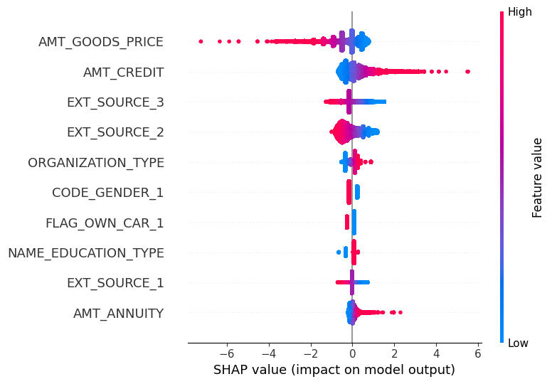

```python
shap.summary_plot(shap_values.values, features=X_test_scaled_t, max_display=10)
```

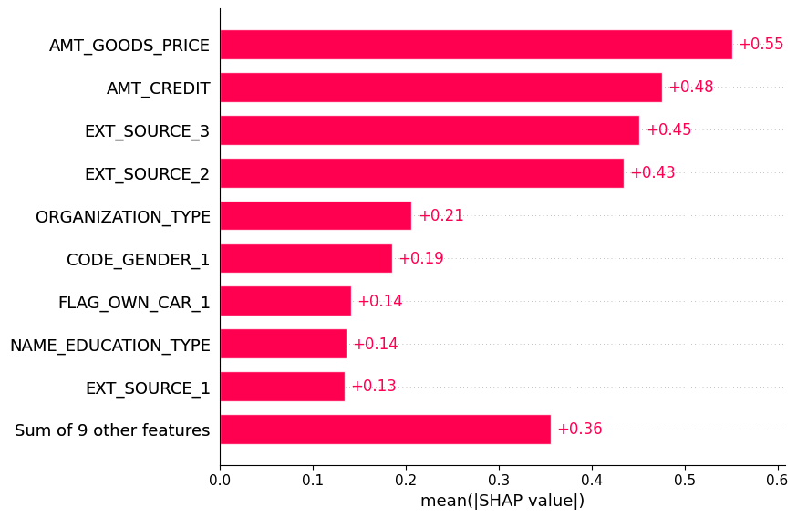

```python
shap.plots.bar(shap_values)
```

La gráfica siguiente muestra el impacto promedio de cada variable en las predicciones del modelo, ordenadas de mayor a menor. Como era de esperar, el precio de los bienes para los que se concede el préstamo es la variable más importante, seguida por el importe del crédito, que también tiene un gran peso en las decisiones del modelo.

Las variables externas también influyen de manera significativa. En cambio, variables como el tipo de organización, género y propiedad de un auto tienen un impacto menor, pero siguen siendo útiles. Las variables demográficas, como el tipo de educación, aportan menos en comparación con las variables financieras.

Al analizar la explicabilidad global, podemos ver que el modelo está principalmente influenciado por factores financieros, pero las variables demográficas y organizacionales también ayudan a complementar la información.

## Explicabilidad local:

La explicabilidad local es la forma de entender cómo cada característica afecta a una predicción específica de nuestro modelo. En lugar de ver el modelo como un todo, podemos ver qué importancia tiene cada variable para una predicción en particular, lo que nos ayuda a entender por qué el modelo tomó una decisión en un caso concreto. Esto es especialmente útil si tenemos que explicar a un cliente por qué su préstamo no fue aprobado.

Ahora mostramos la explicabilidad local del modelo para varios clientes específicos.

```python
shap.force_plot(
    explainer.expected_value,
    shap_values[0].values,
    X_test_scaled_t.iloc[0, :]
)
```

[output not shown]

```python
shap.force_plot(
    explainer.expected_value,
    shap_values[1].values,
    X_test_scaled_t.iloc[0, :]
)
```

[output not shown]

# Conclusiones finales del proyecto

En este proyecto, el objetivo principal fue ayudar a un banco a tomar decisiones más acertadas al aprobar préstamos, basándonos en datos históricos para identificar los patrones que distinguen a los clientes que cumplen con sus pagos de los que no. Al hacerlo, el banco puede reducir el riesgo de impagos y evitar rechazar a clientes potencialmente buenos pagadores.

Durante el análisis, lo primero que encontramos fue que los datos estaban bastante desbalanceados, ya que la mayoría de los clientes pagaban sin problemas. Este desbalance fue un reto interesante, ya que me permitió profundizar en cómo afecta a las decisiones del modelo y en cómo se debe tratar con técnicas como el oversampling y undersampling para evitar que el modelo se sesgue hacia la mayoría de los buenos pagadores.

A lo largo del proceso, probamos varios enfoques y modelos. Tras un análisis cuidadoso, la regresión logística resultó ser la mejor opción en este caso. Aunque exploramos otros modelos como Random Forest y XGBoost, la regresión logística me ha dado los mejores resultados a la hora de predecir con precisión el riesgo de impago.

Para evaluar el rendimiento del modelo, nos centramos en métricas como la precisión, recall, F1-Score y AUC-ROC, ya que, con datos desbalanceados, es crucial medir bien los falsos positivos y negativos. A pesar de las dificultades del desbalanceo, el modelo logró buenos resultados, asegurándonos de que las decisiones que tome el banco sean justas y basadas en información precisa.

Al estudiar la explicabilidad del modelo, descubrimos que algunas variables eran más influyentes de lo que pensábamos, como el precio de los bienes asociados al préstamo. Por otro lado, otras variables, como el género del cliente, no tuvieron el impacto esperado, lo que nos recordó la importancia de evitar sesgos en los modelos.

En resumen, este proyecto me ha permitido aplicar los conicimiento aprendendidos durante las clases de aprendizaje automático en un contexto semi-real, mostrando cómo la selección de modelos y su evaluación deben estar siempre alineadas con los objetivos del cliente.